# main3

```python
import pandas as pd
import matplotlib.pyplot as plt
import numpy as np

# Wczytanie danych PM10 dla dwóch wybranych miast
gliwice = pd.read_excel("Miasta/Gliwice 24h 2007-2014.xlsx", header=3)
tychy = pd.read_excel("Miasta/Tychy 24h 2007-2014.xlsx", header=3)

print("Gliwice:")
display(gliwice.head())

print("Tychy:")
display(tychy.head())
```

```
Gliwice:
```

|  | Unnamed: 0 | NO | NO2 | NOx | PM10 | PM2.5 | SO2 | cisnienie | kier | opad_atm | predk | prom | temp | wilg |
| --- | --- | --- | --- | --- | --- | --- | --- | --- | --- | --- | --- | --- | --- | --- |
| 0 | Data | 1g | 1g | 1g | 1g | 24g | 1g | 1g | 1g | 1g | 1g | 1g | 1g | 1g |
| 1 | 2007-01-01 | NaN | 9.521739 | NaN | 14.666667 | NaN | 4 | NaN | NaN | NaN | NaN | NaN | NaN | NaN |
| 2 | 2007-01-02 | NaN | 17.347826 | NaN | 22.291667 | NaN | NaN | NaN | NaN | NaN | NaN | NaN | NaN | NaN |
| 3 | 2007-01-03 | NaN | 17.47619 | NaN | 17.217391 | NaN | 2.75 | NaN | NaN | NaN | NaN | NaN | NaN | NaN |
| 4 | 2007-01-04 | NaN | 20.047619 | NaN | 13.333333 | NaN | 10.952381 | NaN | NaN | NaN | NaN | NaN | NaN | NaN |

```
Tychy:
```

|  | Unnamed: 0 | NO | NO2 | NOx | O3 | PM10 | SO2 | cisnienie | kier | opad_atm | predk | prom | temp | wilg |
| --- | --- | --- | --- | --- | --- | --- | --- | --- | --- | --- | --- | --- | --- | --- |
| 0 | Data | 1g | 1g | 1g | 1g | 1g | 1g | 1g | 1g | 1g | 1g | 1g | 1g | 1g |
| 1 | 2007-01-01 | NaN | 11.217391 | NaN | 50.416667 | 10.125 | 9.608696 | NaN | NaN | NaN | NaN | NaN | NaN | NaN |
| 2 | 2007-01-02 | NaN | 17.956522 | NaN | 42.652174 | 17.291667 | 9.869565 | NaN | NaN | NaN | NaN | NaN | NaN | NaN |
| 3 | 2007-01-03 | NaN | 17.652174 | NaN | 33.608696 | 18.583333 | 8.782609 | NaN | NaN | NaN | NaN | NaN | NaN | NaN |
| 4 | 2007-01-04 | NaN | 11.956522 | NaN | 44.782609 | 8.333333 | 8.173913 | NaN | NaN | NaN | NaN | NaN | NaN | NaN |

Dane dotyczące zanieczyszczenia powietrza zostały wczytane z plików Excel dla dwóch miast: Gliwic i Tychów. W analizie wykorzystano zmienną PM10, czyli średnie dobowe stężenie pyłu zawieszonego.

```python
# Uporządkowanie danych z plików miejskich

gliwice = gliwice.rename(columns={"Unnamed: 0": "Data"})
tychy = tychy.rename(columns={"Unnamed: 0": "Data"})

# Usunięcie technicznego wiersza z jednostkami pomiaru
gliwice = gliwice[gliwice["Data"] != "Data"].copy()
tychy = tychy[tychy["Data"] != "Data"].copy()

# Konwersja daty i PM10 do poprawnych typów danych
gliwice["Data"] = pd.to_datetime(gliwice["Data"], errors="coerce")
tychy["Data"] = pd.to_datetime(tychy["Data"], errors="coerce")

gliwice["PM10"] = pd.to_numeric(gliwice["PM10"], errors="coerce")
tychy["PM10"] = pd.to_numeric(tychy["PM10"], errors="coerce")

# Pozostawienie tylko kolumn potrzebnych w projekcie
gliwice = gliwice[["Data", "PM10"]].copy()
tychy = tychy[["Data", "PM10"]].copy()

display(gliwice.head())
display(tychy.head())
```

|  | Data | PM10 |
| --- | --- | --- |
| 1 | 2007-01-01 | 14.666667 |
| 2 | 2007-01-02 | 22.291667 |
| 3 | 2007-01-03 | 17.217391 |
| 4 | 2007-01-04 | 13.333333 |
| 5 | 2007-01-05 | 13.791667 |

|  | Data | PM10 |
| --- | --- | --- |
| 1 | 2007-01-01 | 10.125000 |
| 2 | 2007-01-02 | 17.291667 |
| 3 | 2007-01-03 | 18.583333 |
| 4 | 2007-01-04 | 8.333333 |
| 5 | 2007-01-05 | 17.625000 |

```python
# Analiza braków danych w dziennych danych PM10

braki_pm10 = pd.DataFrame({
    "Miasto": ["Gliwice", "Tychy"],
    "Liczba braków PM10": [
        gliwice["PM10"].isna().sum(),
        tychy["PM10"].isna().sum()
    ],
    "Procent braków PM10": [
        gliwice["PM10"].isna().mean() * 100,
        tychy["PM10"].isna().mean() * 100
    ]
})

display(braki_pm10)
```

|  | Miasto | Liczba braków PM10 | Procent braków PM10 |
| --- | --- | --- | --- |
| 0 | Gliwice | 366 | 12.625043 |
| 1 | Tychy | 214 | 7.394610 |

```python
# Agregacja danych dziennych do danych miesięcznych

gliwice["Rok"] = gliwice["Data"].dt.year
gliwice["Miesiac"] = gliwice["Data"].dt.month

tychy["Rok"] = tychy["Data"].dt.year
tychy["Miesiac"] = tychy["Data"].dt.month

gliwice_month = (
    gliwice.groupby(["Rok", "Miesiac"])["PM10"]
    .mean()
    .reset_index()
)

tychy_month = (
    tychy.groupby(["Rok", "Miesiac"])["PM10"]
    .mean()
    .reset_index()
)

gliwice_month["Data"] = pd.to_datetime(
    gliwice_month["Rok"].astype(str) + "-" + gliwice_month["Miesiac"].astype(str) + "-01"
)

tychy_month["Data"] = pd.to_datetime(
    tychy_month["Rok"].astype(str) + "-" + tychy_month["Miesiac"].astype(str) + "-01"
)

display(gliwice_month.head())
display(tychy_month.head())
```

|  | Rok | Miesiac | PM10 | Data |
| --- | --- | --- | --- | --- |
| 0 | 2007 | 1 | 19.187994 | 2007-01-01 |
| 1 | 2007 | 2 | 38.279270 | 2007-02-01 |
| 2 | 2007 | 3 | 62.601449 | 2007-03-01 |
| 3 | 2007 | 4 | 44.388164 | 2007-04-01 |
| 4 | 2007 | 5 | 28.912873 | 2007-05-01 |

|  | Rok | Miesiac | PM10 | Data |
| --- | --- | --- | --- | --- |
| 0 | 2007 | 1 | 19.922421 | 2007-01-01 |
| 1 | 2007 | 2 | 43.105945 | 2007-02-01 |
| 2 | 2007 | 3 | 49.478103 | 2007-03-01 |
| 3 | 2007 | 4 | 32.577778 | 2007-04-01 |
| 4 | 2007 | 5 | 30.971774 | 2007-05-01 |

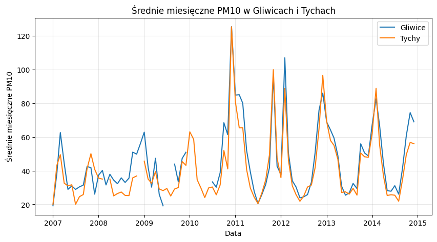

```python
plt.figure(figsize=(10, 5))
plt.plot(gliwice_month["Data"], gliwice_month["PM10"], label="Gliwice")
plt.plot(tychy_month["Data"], tychy_month["PM10"], label="Tychy")
plt.title("Średnie miesięczne PM10 w Gliwicach i Tychach")
plt.xlabel("Data")
plt.ylabel("Średnie miesięczne PM10")
plt.legend()
plt.grid(alpha=0.3)
plt.show()
```

```python
# 2. Wczytanie i przygotowanie danych chorobowych J45
import pandas as pd
import subprocess
import io

# Eksport tabeli z bazy .mdb do DataFrame
cmd = ["mdb-export", "SUM_2015-03-19.mdb", "SUM_2007_2014"]
result = subprocess.run(cmd, capture_output=True, text=True)

if result.returncode != 0:
    print("Błąd podczas eksportu danych z pliku .mdb:")
    print(result.stderr)
else:
    df = pd.read_csv(io.StringIO(result.stdout))
    display(df.head())
    print(df.columns)
```

|  | KOD_TERYT_PACJENTA | GMINA_PACJENTA | DATA | ROZPOZNANIE | PLEC | WIEK | LB_OSOB |
| --- | --- | --- | --- | --- | --- | --- | --- |
| 0 | 2415041 | Wodzisław Śląski | 09/24/07 00:00:00 | J45 | 1.0 | 68.0 | 1 |
| 1 | 2469011 | Katowice | 02/23/07 00:00:00 | J45 | 1.0 | 30.0 | 1 |
| 2 | 2475011 | Sosnowiec | 07/11/07 00:00:00 | J45 | 1.0 | 50.0 | 1 |
| 3 | 2469011 | Katowice | 04/24/07 00:00:00 | J44 | 1.0 | 54.0 | 1 |
| 4 | 2469011 | Katowice | 07/12/07 00:00:00 | J45.0 | 2.0 | 51.0 | 1 |

```
Index(['KOD_TERYT_PACJENTA', 'GMINA_PACJENTA', 'DATA', 'ROZPOZNANIE', 'PLEC',
       'WIEK', 'LB_OSOB'],
      dtype='str')
```

```python
# Filtrowanie danych chorobowych

df_j45 = df[
    df["ROZPOZNANIE"].str.startswith("J45", na=False)
].copy()

df_j45 = df_j45[
    df_j45["GMINA_PACJENTA"].isin(["Gliwice", "Tychy"])
].copy()

display(df_j45.head())
print("Liczba rekordów po filtrowaniu:", df_j45.shape[0])
```

|  | KOD_TERYT_PACJENTA | GMINA_PACJENTA | DATA | ROZPOZNANIE | PLEC | WIEK | LB_OSOB |
| --- | --- | --- | --- | --- | --- | --- | --- |
| 8 | 2466011 | Gliwice | 11/08/07 00:00:00 | J45 | 1.0 | NaN | 9 |
| 17 | 2477011 | Tychy | 11/30/07 00:00:00 | J45 | 2.0 | 45.0 | 1 |
| 19 | 2477011 | Tychy | 04/02/07 00:00:00 | J45 | 1.0 | 49.0 | 2 |
| 20 | 2466011 | Gliwice | 03/26/07 00:00:00 | J45 | 2.0 | 42.0 | 1 |
| 33 | 2466011 | Gliwice | 03/30/07 00:00:00 | J45 | 2.0 | 46.0 | 2 |

```
Liczba rekordów po filtrowaniu: 215482
```

```python
# Agregacja danych chorobowych do poziomu dziennego

df_j45["DATA"] = pd.to_datetime(
    df_j45["DATA"],
    format="%m/%d/%y %H:%M:%S",
    errors="coerce"
)

df_j45_grouped = (
    df_j45.groupby(["DATA", "GMINA_PACJENTA"])["LB_OSOB"]
    .sum()
    .reset_index()
)

df_j45_grouped = df_j45_grouped.rename(columns={
    "DATA": "Data",
    "GMINA_PACJENTA": "Miasto",
    "LB_OSOB": "J45"
})

display(df_j45_grouped.head(10))
```

|  | Data | Miasto | J45 |
| --- | --- | --- | --- |
| 0 | 2007-01-01 | Gliwice | 2 |
| 1 | 2007-01-02 | Gliwice | 82 |
| 2 | 2007-01-02 | Tychy | 61 |
| 3 | 2007-01-03 | Gliwice | 104 |
| 4 | 2007-01-03 | Tychy | 57 |
| 5 | 2007-01-04 | Gliwice | 70 |
| 6 | 2007-01-04 | Tychy | 65 |
| 7 | 2007-01-05 | Gliwice | 90 |
| 8 | 2007-01-05 | Tychy | 65 |
| 9 | 2007-01-06 | Gliwice | 2 |

```python
# Agregacja J45 do poziomu miesięcznego

df_j45_grouped["Rok"] = df_j45_grouped["Data"].dt.year
df_j45_grouped["Miesiac"] = df_j45_grouped["Data"].dt.month

j45_month = (
    df_j45_grouped.groupby(["Rok", "Miesiac", "Miasto"])["J45"]
    .sum()
    .reset_index()
)

# Dodanie informacji o mieście do danych PM10
gliwice_month["Miasto"] = "Gliwice"
tychy_month["Miasto"] = "Tychy"

# Połączenie danych PM10 i J45
pm10_all = pd.concat([gliwice_month, tychy_month], ignore_index=True)

df_all = pd.merge(
    pm10_all[["Rok", "Miesiac", "PM10", "Miasto"]],
    j45_month,
    on=["Rok", "Miesiac", "Miasto"],
    how="inner"
)

display(df_all.head(10))
print("Rozmiar finalnego zbioru:", df_all.shape)
```

|  | Rok | Miesiac | PM10 | Miasto | J45 |
| --- | --- | --- | --- | --- | --- |
| 0 | 2007 | 1 | 19.187994 | Gliwice | 1941 |
| 1 | 2007 | 2 | 38.279270 | Gliwice | 1707 |
| 2 | 2007 | 3 | 62.601449 | Gliwice | 2031 |
| 3 | 2007 | 4 | 44.388164 | Gliwice | 1829 |
| 4 | 2007 | 5 | 28.912873 | Gliwice | 1810 |
| 5 | 2007 | 6 | 30.937500 | Gliwice | 1726 |
| 6 | 2007 | 7 | 28.869331 | Gliwice | 1403 |
| 7 | 2007 | 8 | 30.387915 | Gliwice | 1235 |
| 8 | 2007 | 9 | 31.425928 | Gliwice | 1618 |
| 9 | 2007 | 10 | 42.401590 | Gliwice | 1784 |

```
Rozmiar finalnego zbioru: (192, 5)
```

```python
# Dodanie liczby mieszkańców i standaryzacja liczby przypadków J45

population_data = pd.DataFrame({
    "Rok": [
        2007, 2008, 2009, 2010, 2011, 2012, 2013, 2014,
        2007, 2008, 2009, 2010, 2011, 2012, 2013, 2014
    ],
    "Miasto": [
        "Gliwice", "Gliwice", "Gliwice", "Gliwice", "Gliwice", "Gliwice", "Gliwice", "Gliwice",
        "Tychy", "Tychy", "Tychy", "Tychy", "Tychy", "Tychy", "Tychy", "Tychy"
    ],
    "Ludnosc": [
        197393, 196668, 196167, 187830, 186868, 186210, 185450, 184415,
        129776, 129475, 129449, 129507, 129322, 129112, 128799, 128621
    ]
})

# Dołączenie liczby mieszkańców do finalnego datasetu
df_all = pd.merge(
    df_all,
    population_data,
    on=["Rok", "Miasto"],
    how="left"
)

# Obliczenie liczby przypadków J45 na 100 000 mieszkańców
df_all["J45_na_100k"] = df_all["J45"] / df_all["Ludnosc"] * 100000

display(df_all.head(10))
print(df_all[["Rok", "Miasto", "Ludnosc"]].drop_duplicates().head(20))
```

|  | Rok | Miesiac | PM10 | Miasto | J45 | Ludnosc | J45_na_100k |
| --- | --- | --- | --- | --- | --- | --- | --- |
| 0 | 2007 | 1 | 19.187994 | Gliwice | 1941 | 197393 | 983.317544 |
| 1 | 2007 | 2 | 38.279270 | Gliwice | 1707 | 197393 | 864.772307 |
| 2 | 2007 | 3 | 62.601449 | Gliwice | 2031 | 197393 | 1028.911866 |
| 3 | 2007 | 4 | 44.388164 | Gliwice | 1829 | 197393 | 926.577943 |
| 4 | 2007 | 5 | 28.912873 | Gliwice | 1810 | 197393 | 916.952476 |
| 5 | 2007 | 6 | 30.937500 | Gliwice | 1726 | 197393 | 874.397775 |
| 6 | 2007 | 7 | 28.869331 | Gliwice | 1403 | 197393 | 710.764819 |
| 7 | 2007 | 8 | 30.387915 | Gliwice | 1235 | 197393 | 625.655418 |
| 8 | 2007 | 9 | 31.425928 | Gliwice | 1618 | 197393 | 819.684589 |
| 9 | 2007 | 10 | 42.401590 | Gliwice | 1784 | 197393 | 903.780782 |

```
      Rok   Miasto  Ludnosc
0    2007  Gliwice   197393
12   2008  Gliwice   196668
24   2009  Gliwice   196167
36   2010  Gliwice   187830
48   2011  Gliwice   186868
60   2012  Gliwice   186210
72   2013  Gliwice   185450
84   2014  Gliwice   184415
96   2007    Tychy   129776
108  2008    Tychy   129475
120  2009    Tychy   129449
132  2010    Tychy   129507
144  2011    Tychy   129322
156  2012    Tychy   129112
168  2013    Tychy   128799
180  2014    Tychy   128621
```

```python
# Analiza braków danych i przygotowanie zbioru do dalszych obliczeń

df_all["PM10"] = pd.to_numeric(df_all["PM10"], errors="coerce")
df_all["J45"] = pd.to_numeric(df_all["J45"], errors="coerce")
df_all["Ludnosc"] = pd.to_numeric(df_all["Ludnosc"], errors="coerce")
df_all["J45_na_100k"] = pd.to_numeric(df_all["J45_na_100k"], errors="coerce")

# Utworzenie daty miesięcznej
df_all["Data"] = pd.to_datetime(
    df_all["Rok"].astype(str) + "-" + df_all["Miesiac"].astype(str) + "-01"
)

print("Braki danych w df_all:")
print(df_all.isna().sum())

print("\nProcent braków danych w df_all:")
print((df_all.isna().mean() * 100).round(2))

# Do dalszych analiz usuwamy obserwacje z brakującymi wartościami głównych cech
df_clean = df_all.dropna(subset=["PM10", "J45", "J45_na_100k"]).copy()

print("\nLiczba wierszy przed usunięciem braków:", df_all.shape[0])
print("Liczba wierszy po usunięciu braków:", df_clean.shape[0])
print("Liczba usuniętych wierszy:", df_all.shape[0] - df_clean.shape[0])

display(df_clean.head())
```

```
Braki danych w df_all:
Rok             0
Miesiac         0
PM10           10
Miasto          0
J45             0
Ludnosc         0
J45_na_100k     0
Data            0
dtype: int64

Procent braków danych w df_all:
Rok            0.00
Miesiac        0.00
PM10           5.21
Miasto         0.00
J45            0.00
Ludnosc        0.00
J45_na_100k    0.00
Data           0.00
dtype: float64

Liczba wierszy przed usunięciem braków: 192
Liczba wierszy po usunięciu braków: 182
Liczba usuniętych wierszy: 10
```

|  | Rok | Miesiac | PM10 | Miasto | J45 | Ludnosc | J45_na_100k | Data |
| --- | --- | --- | --- | --- | --- | --- | --- | --- |
| 0 | 2007 | 1 | 19.187994 | Gliwice | 1941 | 197393 | 983.317544 | 2007-01-01 |
| 1 | 2007 | 2 | 38.279270 | Gliwice | 1707 | 197393 | 864.772307 | 2007-02-01 |
| 2 | 2007 | 3 | 62.601449 | Gliwice | 2031 | 197393 | 1028.911866 | 2007-03-01 |
| 3 | 2007 | 4 | 44.388164 | Gliwice | 1829 | 197393 | 926.577943 | 2007-04-01 |
| 4 | 2007 | 5 | 28.912873 | Gliwice | 1810 | 197393 | 916.952476 | 2007-05-01 |

```python
# Podstawowe statystyki dla dwóch badanych cech
statystyki = df_clean[["PM10", "J45", "J45_na_100k"]].describe()

display(statystyki)
def punkt_srodkowy(series):
    return (series.min() + series.max()) / 2

podsumowanie = pd.DataFrame({
    "Średnia": [
        df_clean["PM10"].mean(),
        df_clean["J45"].mean(),
        df_clean["J45_na_100k"].mean()
    ],
    "Mediana": [
        df_clean["PM10"].median(),
        df_clean["J45"].median(),
        df_clean["J45_na_100k"].median()
    ],
    "Punkt środkowy": [
        punkt_srodkowy(df_clean["PM10"]),
        punkt_srodkowy(df_clean["J45"]),
        punkt_srodkowy(df_clean["J45_na_100k"])
    ],
    "Minimum": [
        df_clean["PM10"].min(),
        df_clean["J45"].min(),
        df_clean["J45_na_100k"].min()
    ],
    "Maksimum": [
        df_clean["PM10"].max(),
        df_clean["J45"].max(),
        df_clean["J45_na_100k"].max()
    ],
    "Odchylenie standardowe": [
        df_clean["PM10"].std(),
        df_clean["J45"].std(),
        df_clean["J45_na_100k"].std()
    ]
}, index=["PM10", "J45", "J45_na_100k"])

display(podsumowanie)
```

|  | PM10 | J45 | J45_na_100k |
| --- | --- | --- | --- |
| count | 182.000000 | 182.000000 | 182.000000 |
| mean | 43.281112 | 1401.263736 | 896.754378 |
| std | 20.181264 | 271.296777 | 160.894968 |
| min | 19.170057 | 645.000000 | 500.780286 |
| 25% | 29.200075 | 1223.000000 | 790.641208 |
| 50% | 36.358458 | 1402.500000 | 889.307681 |
| 75% | 50.739338 | 1592.500000 | 1010.102574 |
| max | 125.336831 | 2031.000000 | 1337.746091 |

|  | Średnia | Mediana | Punkt środkowy | Minimum | Maksimum | Odchylenie standardowe |
| --- | --- | --- | --- | --- | --- | --- |
| PM10 | 43.281112 | 36.358458 | 72.253444 | 19.170057 | 125.336831 | 20.181264 |
| J45 | 1401.263736 | 1402.500000 | 1338.000000 | 645.000000 | 2031.000000 | 271.296777 |
| J45_na_100k | 896.754378 | 889.307681 | 919.263188 | 500.780286 | 1337.746091 | 160.894968 |

```python
# Statystyki z podziałem na miasta
statystyki_miasta = df_clean.groupby("Miasto")[["PM10", "J45", "J45_na_100k"]].agg(
    ["count", "mean", "median", "min", "max", "std"]
)

display(statystyki_miasta)
```

| Miasto | PM10 count | PM10 mean | PM10 median | PM10 min | PM10 max | PM10 std | J45 count | J45 mean | J45 median | J45 min | J45 max | J45 std | J45_na_100k count | J45_na_100k mean | J45_na_100k median | J45_na_100k min | J45_na_100k max | J45_na_100k std |
| --- | --- | --- | --- | --- | --- | --- | --- | --- | --- | --- | --- | --- | --- | --- | --- | --- | --- | --- |
| Gliwice | 88 | 45.77362 | 39.654329 | 19.170057 | 125.336831 | 20.821409 | 88 | 1563.681818 | 1582.5 | 985 | 2031 | 229.380953 | 88 | 822.245747 | 834.639496 | 530.843859 | 1028.911866 | 116.974684 |
| Tychy | 94 | 40.94770 | 34.886769 | 19.922421 | 125.251120 | 19.383669 | 94 | 1249.212766 | 1284.5 | 645 | 1730 | 213.766825 | 94 | 966.507138 | 996.028956 | 500.780286 | 1337.746091 | 165.564092 |

```python
# Średnie wartości PM10 i J45 dla każdego miasta
mean_values = df_clean.groupby("Miasto")[["PM10", "J45", "J45_na_100k"]].mean()

display(mean_values)
```

| Miasto | PM10 | J45 | J45_na_100k |
| --- | --- | --- | --- |
| Gliwice | 45.77362 | 1563.681818 | 822.245747 |
| Tychy | 40.94770 | 1249.212766 | 966.507138 |

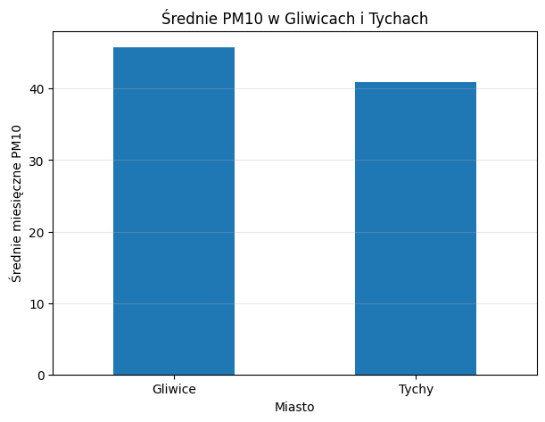

```python
# Wykres słupkowy średnich wartości PM10
plt.figure(figsize=(7, 5))
mean_values["PM10"].plot(kind="bar")
plt.title("Średnie PM10 w Gliwicach i Tychach")
plt.xlabel("Miasto")
plt.ylabel("Średnie miesięczne PM10")
plt.xticks(rotation=0)
plt.grid(axis="y", alpha=0.3)
plt.show()
```

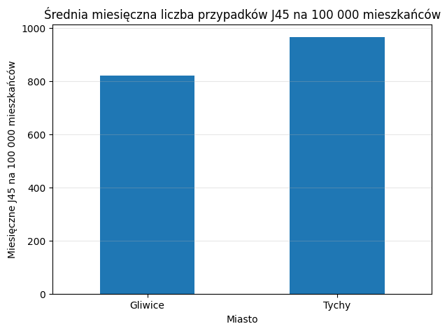

```python
# Wykres słupkowy średnich wartości J45
plt.figure(figsize=(7, 5))
mean_values["J45_na_100k"].plot(kind="bar")
plt.title("Średnia miesięczna liczba przypadków J45 na 100 000 mieszkańców")
plt.xlabel("Miasto")
plt.ylabel("Miesięczne J45 na 100 000 mieszkańców")
plt.xticks(rotation=0)
plt.grid(axis="y", alpha=0.3)
plt.show()
```

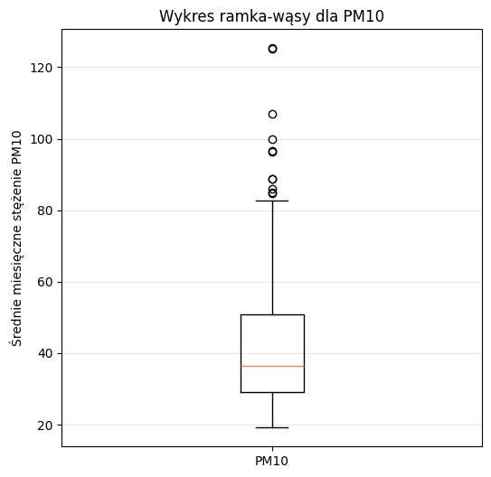

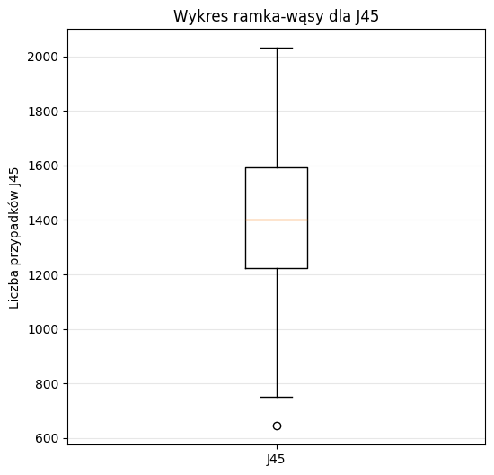

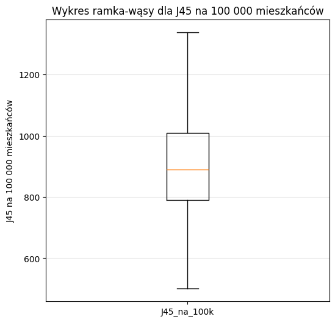

```python
# Boxploty dla PM10 i J45
import matplotlib.pyplot as plt

# upewniamy się, że PM10 i J45 są liczbami i nie mają braków
pm10_values = df_clean["PM10"].dropna()
j45_values = df_clean["J45"].dropna()
j45_rate_values = df_clean["J45_na_100k"].dropna()

plt.figure(figsize=(6, 6))
plt.boxplot(pm10_values, vert=True, tick_labels=["PM10"])
plt.title("Wykres ramka-wąsy dla PM10")
plt.ylabel("Średnie miesięczne stężenie PM10")
plt.grid(axis="y", alpha=0.3)
plt.show()

plt.figure(figsize=(6, 6))
plt.boxplot(j45_values, vert=True, tick_labels=["J45"])
plt.title("Wykres ramka-wąsy dla J45")
plt.ylabel("Liczba przypadków J45")
plt.grid(axis="y", alpha=0.3)
plt.show()

plt.figure(figsize=(6, 6))
plt.boxplot(j45_rate_values, vert=True, tick_labels=["J45_na_100k"])
plt.title("Wykres ramka-wąsy dla J45 na 100 000 mieszkańców")
plt.ylabel("J45 na 100 000 mieszkańców")
plt.grid(axis="y", alpha=0.3)
plt.show()
```

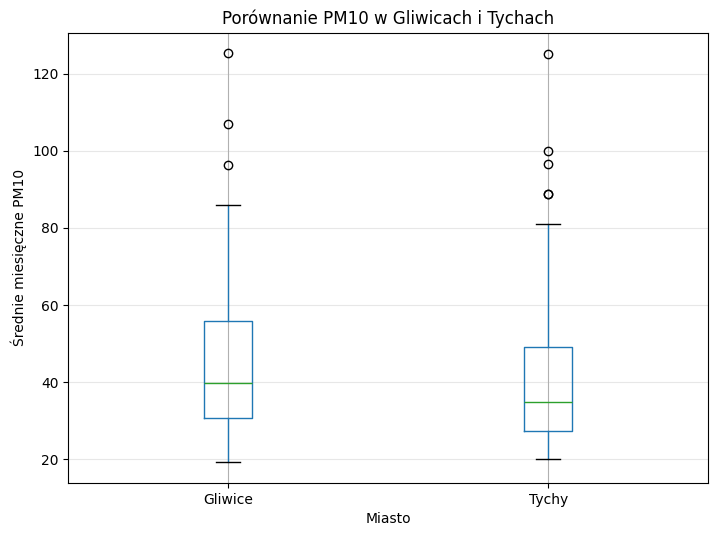

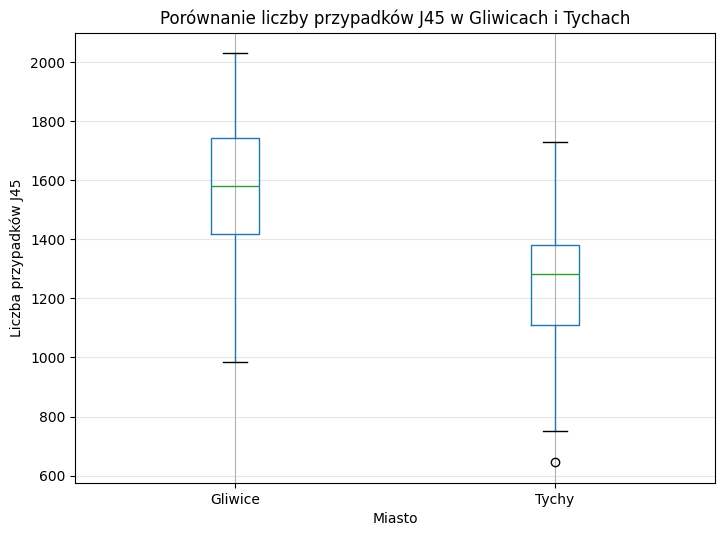

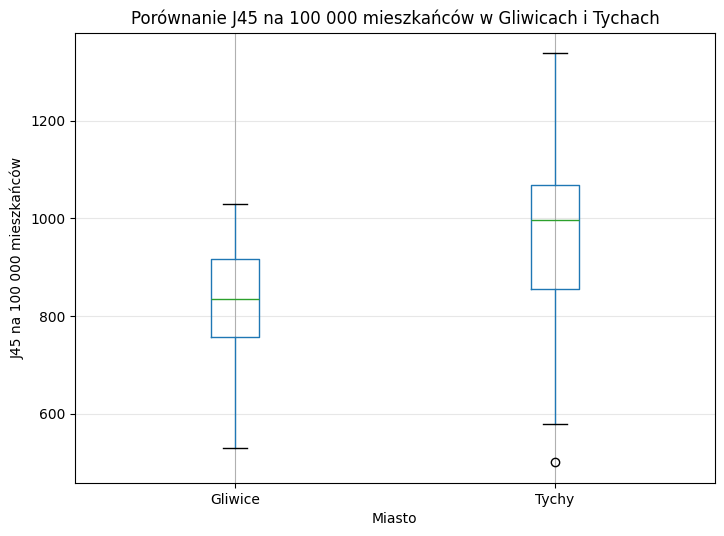

```python
# Boxplot z podziałem na miasta
ax = df_clean.boxplot(column="PM10", by="Miasto", figsize=(8, 6))
plt.title("Porównanie PM10 w Gliwicach i Tychach")
plt.suptitle("")
plt.xlabel("Miasto")
plt.ylabel("Średnie miesięczne PM10")
plt.grid(axis="y", alpha=0.3)
plt.show()

# Dla J45
ax = df_clean.boxplot(column="J45", by="Miasto", figsize=(8, 6))
plt.title("Porównanie liczby przypadków J45 w Gliwicach i Tychach")
plt.suptitle("")
plt.xlabel("Miasto")
plt.ylabel("Liczba przypadków J45")
plt.grid(axis="y", alpha=0.3)
plt.show()

# Dla J45 na 100 000 mieszkańców
ax = df_clean.boxplot(column="J45_na_100k", by="Miasto", figsize=(8, 6))
plt.title("Porównanie J45 na 100 000 mieszkańców w Gliwicach i Tychach")
plt.suptitle("")
plt.xlabel("Miasto")
plt.ylabel("J45 na 100 000 mieszkańców")
plt.grid(axis="y", alpha=0.3)
plt.show()
```

```python
# Outliery dla PM10 i J45
def znajdz_outliery_iqr(df, column):
    Q1 = df[column].quantile(0.25)
    Q3 = df[column].quantile(0.75)
    IQR = Q3 - Q1

    dolna_granica = Q1 - 1.5 * IQR
    gorna_granica = Q3 + 1.5 * IQR

    outliers = df[(df[column] < dolna_granica) | (df[column] > gorna_granica)]

    print(f"Zmienna: {column}")
    print("Q1:", Q1)
    print("Q3:", Q3)
    print("IQR:", IQR)
    print("Dolna granica:", dolna_granica)
    print("Górna granica:", gorna_granica)
    print("Liczba outlierów:", len(outliers))

    return outliers

outliers_pm10 = znajdz_outliery_iqr(df_clean, "PM10")
display(outliers_pm10)

outliers_j45 = znajdz_outliery_iqr(df_clean, "J45")
display(outliers_j45)

outliers_j45_rate = znajdz_outliery_iqr(df_clean, "J45_na_100k")
display(outliers_j45_rate)
```

```
Zmienna: PM10
Q1: 29.20007495180271
Q3: 50.73933836647586
IQR: 21.539263414673155
Dolna granica: -3.1088201702070215
Górna granica: 83.0482334884856
Liczba outlierów: 11
```

|  | Rok | Miesiac | PM10 | Miasto | J45 | Ludnosc | J45_na_100k | Data |
| --- | --- | --- | --- | --- | --- | --- | --- | --- |
| 47 | 2010 | 12 | 125.336831 | Gliwice | 1457 | 187830 | 775.701432 | 2010-12-01 |
| 48 | 2011 | 1 | 84.818579 | Gliwice | 1580 | 186868 | 845.516621 | 2011-01-01 |
| 49 | 2011 | 2 | 85.020880 | Gliwice | 1585 | 186868 | 848.192307 | 2011-02-01 |
| 58 | 2011 | 11 | 96.300522 | Gliwice | 1882 | 186868 | 1007.128026 | 2011-11-01 |
| 61 | 2012 | 2 | 106.891304 | Gliwice | 1549 | 186210 | 831.856506 | 2012-02-01 |
| 71 | 2012 | 12 | 86.001651 | Gliwice | 1154 | 186210 | 619.730412 | 2012-12-01 |
| 143 | 2010 | 12 | 125.251120 | Tychy | 1312 | 129507 | 1013.072652 | 2010-12-01 |
| 154 | 2011 | 11 | 99.882126 | Tychy | 1532 | 129322 | 1184.639891 | 2011-11-01 |
| 157 | 2012 | 2 | 88.788793 | Tychy | 1418 | 129112 | 1098.271268 | 2012-02-01 |
| 167 | 2012 | 12 | 96.485215 | Tychy | 753 | 129112 | 583.214573 | 2012-12-01 |
| 181 | 2014 | 2 | 88.791667 | Tychy | 1375 | 128621 | 1069.032273 | 2014-02-01 |

```
Zmienna: J45
Q1: 1223.0
Q3: 1592.5
IQR: 369.5
Dolna granica: 668.75
Górna granica: 2146.75
Liczba outlierów: 1
```

|  | Rok | Miesiac | PM10 | Miasto | J45 | Ludnosc | J45_na_100k | Data |
| --- | --- | --- | --- | --- | --- | --- | --- | --- |
| 179 | 2013 | 12 | 47.929874 | Tychy | 645 | 128799 | 500.780286 | 2013-12-01 |

```
Zmienna: J45_na_100k
Q1: 790.6412076260189
Q3: 1010.1025738406928
IQR: 219.46136621467394
Dolna granica: 461.44915830400794
Górna granica: 1339.2946231627038
Liczba outlierów: 0
```

|  | Rok | Miesiac | PM10 | Miasto | J45 | Ludnosc | J45_na_100k | Data |
| --- | --- | --- | --- | --- | --- | --- | --- | --- |

```python
# Sprawdzenie wpływu outlierów na średnią
# PM10 bez outlierów
Q1_pm10 = df_clean["PM10"].quantile(0.25)
Q3_pm10 = df_clean["PM10"].quantile(0.75)
IQR_pm10 = Q3_pm10 - Q1_pm10

df_pm10_no_outliers = df_clean[
    (df_clean["PM10"] >= Q1_pm10 - 1.5 * IQR_pm10) &
    (df_clean["PM10"] <= Q3_pm10 + 1.5 * IQR_pm10)
]

print("PM10 - średnia z outlierami:", df_clean["PM10"].mean())
print("PM10 - średnia bez outlierów:", df_pm10_no_outliers["PM10"].mean())

print("PM10 - mediana z outlierami:", df_clean["PM10"].median())
print("PM10 - mediana bez outlierów:", df_pm10_no_outliers["PM10"].median())
```

[output not shown]

# II. Testy parametryczne i nieparametryczne

W tej części przeprowadzono testy statystyczne dla dwóch badanych cech: średniego miesięcznego stężenia PM10 oraz miesięcznej liczby przypadków J45. Analiza obejmuje sprawdzenie normalności rozkładu, porównanie wartości między Gliwicami i Tychami za pomocą testów parametrycznych i nieparametrycznych, test chi-kwadrat oraz wyznaczenie przedziałów ufności dla średniej.

```python
# Przygotowanie danych do testów statystycznych

from scipy.stats import shapiro, ttest_ind, mannwhitneyu, ttest_rel, wilcoxon, chisquare
import scipy.stats as st
import numpy as np
import pandas as pd
import matplotlib.pyplot as plt

# Podział danych na miasta
gliwice_data = df_clean[df_clean["Miasto"] == "Gliwice"].copy()
tychy_data = df_clean[df_clean["Miasto"] == "Tychy"].copy()

# Zmienne do testów
gliwice_pm10 = gliwice_data["PM10"].dropna()
tychy_pm10 = tychy_data["PM10"].dropna()

gliwice_j45_rate = gliwice_data["J45_na_100k"].dropna()
tychy_j45_rate = tychy_data["J45_na_100k"].dropna()

print("Liczba obserwacji PM10 - Gliwice:", len(gliwice_pm10))
print("Liczba obserwacji PM10 - Tychy:", len(tychy_pm10))
print("Liczba obserwacji J45 na 100 000 mieszkańców - Gliwice:", len(gliwice_j45_rate))
print("Liczba obserwacji J45 na 100 000 mieszkańców - Tychy:", len(tychy_j45_rate))
```

```
Liczba obserwacji PM10 - Gliwice: 88
Liczba obserwacji PM10 - Tychy: 94
Liczba obserwacji J45 na 100 000 mieszkańców - Gliwice: 88
Liczba obserwacji J45 na 100 000 mieszkańców - Tychy: 94
```

Test Shapiro-Wilka wykorzystano do sprawdzenia, czy rozkład badanych zmiennych jest zbliżony do rozkładu normalnego.

Hipotezy:

- H0: badana zmienna ma rozkład normalny.
- H1: badana zmienna nie ma rozkładu normalnego.

Przyjęto poziom istotności α = 0,05. Jeżeli p-value jest mniejsze lub równe 0,05, odrzuca się hipotezę zerową i uznaje, że rozkład istotnie odbiega od normalnego.

```python
# Test normalności Shapiro-Wilka

# Jeżeli p-value > 0,05, nie ma podstaw do odrzucenia H0.
# Jeżeli p-value ≤ 0,05, odrzucamy H0 i uznajemy, że rozkład odbiega od normalnego.
alpha = 0.05

variables = {
    "PM10 Gliwice": gliwice_pm10,
    "PM10 Tychy": tychy_pm10,
    "J45 na 100k Gliwice": gliwice_j45_rate,
    "J45 na 100k Tychy": tychy_j45_rate
}

for name, data in variables.items():
    stat, p = shapiro(data)
    print(f"{name}: statystyka = {stat:.4f}, p-value = {p:.4f}")

    if p > alpha:
        print("Brak podstaw do odrzucenia H0 - rozkład można uznać za zbliżony do normalnego.\n")
    else:
        print("Odrzucamy H0 - rozkład istotnie odbiega od normalnego.\n")
```

```
PM10 Gliwice: statystyka = 0.8797, p-value = 0.0000
Odrzucamy H0 - rozkład istotnie odbiega od normalnego.

PM10 Tychy: statystyka = 0.8183, p-value = 0.0000
Odrzucamy H0 - rozkład istotnie odbiega od normalnego.

J45 na 100k Gliwice: statystyka = 0.9732, p-value = 0.0648
Brak podstaw do odrzucenia H0 - rozkład można uznać za zbliżony do normalnego.

J45 na 100k Tychy: statystyka = 0.9826, p-value = 0.2475
Brak podstaw do odrzucenia H0 - rozkład można uznać za zbliżony do normalnego.
```

Interpretacja: Dla zmiennej PM10 w obu miastach p-value jest mniejsze od 0,05, dlatego odrzucono hipotezę o normalności rozkładu. Oznacza to, że rozkład PM10 istotnie odbiega od normalnego. Dla zmiennej J45 w Gliwicach i Tychach p-value jest większe od 0,05, dlatego nie ma podstaw do odrzucenia hipotezy o normalności rozkładu.

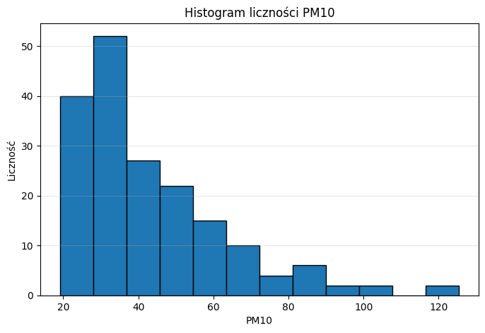

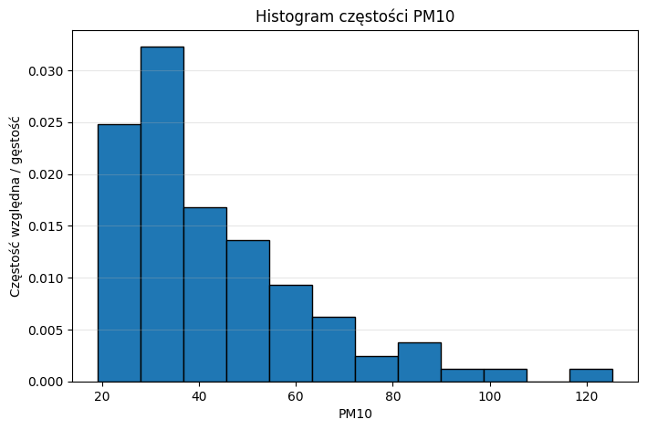

```python
# Histogram liczności i częstości PM10

plt.figure(figsize=(8, 5))
plt.hist(df_clean["PM10"], bins=12, edgecolor="black")
plt.title("Histogram liczności PM10")
plt.xlabel("PM10")
plt.ylabel("Liczność")
plt.grid(axis="y", alpha=0.3)
plt.show()

plt.figure(figsize=(8, 5))
plt.hist(df_clean["PM10"], bins=12, density=True, edgecolor="black")
plt.title("Histogram częstości PM10")
plt.xlabel("PM10")
plt.ylabel("Częstość względna / gęstość")
plt.grid(axis="y", alpha=0.3)
plt.show()
```

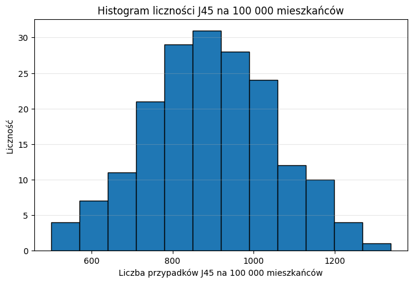

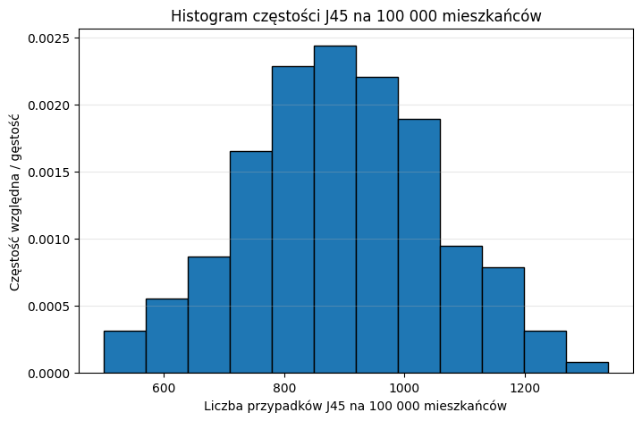

```python
# Histogram liczności i częstości J45

plt.figure(figsize=(8, 5))
plt.hist(df_clean["J45_na_100k"], bins=12, edgecolor="black")
plt.title("Histogram liczności J45 na 100 000 mieszkańców")
plt.xlabel("Liczba przypadków J45 na 100 000 mieszkańców")
plt.ylabel("Liczność")
plt.grid(axis="y", alpha=0.3)
plt.show()

plt.figure(figsize=(8, 5))
plt.hist(df_clean["J45_na_100k"], bins=12, density=True, edgecolor="black")
plt.title("Histogram częstości J45 na 100 000 mieszkańców")
plt.xlabel("Liczba przypadków J45 na 100 000 mieszkańców")
plt.ylabel("Częstość względna / gęstość")
plt.grid(axis="y", alpha=0.3)
plt.show()
```

## 4. Test Welcha dla prób niezależnych

Test Welcha jest parametrycznym testem istotności różnic średnich dla dwóch niezależnych grup. W tym przypadku grupami są dwa miasta: Gliwice i Tychy. Test Welcha wybrano zamiast klasycznego testu t-Studenta, ponieważ nie wymaga założenia równości wariancji w porównywanych grupach.

Hipotezy dla PM10:

- H0: średnie stężenie PM10 w Gliwicach i Tychach jest takie samo.
- H1: średnie stężenie PM10 w Gliwicach i Tychach różni się.

Analogicznie dla J45:

- H0: średnia liczba przypadków J45 w Gliwicach i Tychach jest taka sama.
- H1: średnia liczba przypadków J45 w Gliwicach i Tychach różni się.

```python
# Test Welcha dla PM10 - próby niezależne

t_stat, p_value = ttest_ind(gliwice_pm10, tychy_pm10, equal_var=False)

print("Test Welcha dla PM10")
print("t-statystyka:", t_stat)
print("p-value:", p_value)

if p_value < alpha:
    print("Odrzucamy H0 - średnie PM10 w Gliwicach i Tychach różnią się istotnie.")
else:
    print("Brak podstaw do odrzucenia H0 - nie wykazano istotnej różnicy średnich PM10.")
```

```
Test Welcha dla PM10
t-statystyka: 1.615513529144262
p-value: 0.10798406186893524
Brak podstaw do odrzucenia H0 - nie wykazano istotnej różnicy średnich PM10.
```

```python
t_stat, p_value = ttest_ind(gliwice_j45_rate, tychy_j45_rate, equal_var=False)

print("Test Welcha dla J45 na 100 000 mieszkańców")
print("t-statystyka:", t_stat)
print("p-value:", p_value)

if p_value < alpha:
    print("Odrzucamy H0 - średnia liczba przypadków J45 na 100 000 mieszkańców różni się istotnie między miastami.")
else:
    print("Brak podstaw do odrzucenia H0 - nie wykazano istotnej różnicy średnich J45 na 100 000 mieszkańców.")
```

```
Test Welcha dla J45 na 100 000 mieszkańców
t-statystyka: -6.822559883579599
p-value: 1.5553755364901867e-10
Odrzucamy H0 - średnia liczba przypadków J45 na 100 000 mieszkańców różni się istotnie między miastami.
```

Interpretacja: Dla PM10 wartość p-value wyniosła około 0,108, czyli była większa od 0,05. Nie ma więc podstaw do odrzucenia hipotezy zerowej. Oznacza to, że na podstawie testu Welcha nie wykazano istotnej statystycznie różnicy średniego PM10 między Gliwicami i Tychami.

Dla J45 wartość p-value była znacznie mniejsza od 0,05, dlatego odrzucono hipotezę zerową. Oznacza to, że średnia miesięczna liczba przypadków J45 różni się istotnie między Gliwicami i Tychami.

## 5. Test Manna-Whitneya dla prób niezależnych

Test Manna-Whitneya jest nieparametryczną alternatywą dla testu t-Studenta/Welcha. Nie wymaga założenia normalności rozkładu, dlatego jest szczególnie przydatny w przypadku zmiennej PM10, dla której test Shapiro-Wilka wykazał brak normalności rozkładu.

Hipotezy:

- H0: rozkłady wartości w Gliwicach i Tychach nie różnią się istotnie.
- H1: rozkłady wartości w Gliwicach i Tychach różnią się istotnie.

```python
# Test Manna-Whitneya dla PM10

stat, p_value = mannwhitneyu(gliwice_pm10, tychy_pm10, alternative="two-sided")

print("Test Manna-Whitneya dla PM10")
print("statystyka:", stat)
print("p-value:", p_value)

if p_value < alpha:
    print("Odrzucamy H0 - rozkłady PM10 w miastach różnią się istotnie.")
else:
    print("Brak podstaw do odrzucenia H0 - nie wykazano istotnej różnicy rozkładów PM10.")
```

```
Test Manna-Whitneya dla PM10
statystyka: 4858.0
p-value: 0.04221410133032418
Odrzucamy H0 - rozkłady PM10 w miastach różnią się istotnie.
```

```python
stat, p_value = mannwhitneyu(gliwice_j45_rate, tychy_j45_rate, alternative="two-sided")

print("Test Manna-Whitneya dla J45 na 100 000 mieszkańców")
print("statystyka:", stat)
print("p-value:", p_value)

if p_value < alpha:
    print("Odrzucamy H0 - rozkłady J45 na 100 000 mieszkańców różnią się istotnie między miastami.")
else:
    print("Brak podstaw do odrzucenia H0 - nie wykazano istotnej różnicy rozkładów J45 na 100 000 mieszkańców.")
```

```
Test Manna-Whitneya dla J45 na 100 000 mieszkańców
statystyka: 1915.0
p-value: 4.0554247531192835e-10
Odrzucamy H0 - rozkłady J45 na 100 000 mieszkańców różnią się istotnie między miastami.
```

Interpretacja: Dla PM10 test Manna-Whitneya dał p-value około 0,042, czyli poniżej 0,05. Odrzucono hipotezę zerową, co wskazuje na istotną statystycznie różnicę rozkładów PM10 między Gliwicami i Tychami. Wynik ten różni się od testu Welcha, co może wynikać z nienormalnego rozkładu PM10 oraz obecności wartości odstających.

Dla J45 p-value było znacznie mniejsze od 0,05, dlatego również odrzucono hipotezę zerową. Oznacza to, że rozkłady miesięcznej liczby przypadków J45 różnią się istotnie między miastami.

## 6. Testy dla prób zależnych

Oprócz testów dla prób niezależnych wykonano również testy dla prób zależnych. Dane potraktowano jako sparowane, ponieważ dla każdego miesiąca można zestawić wartość z Gliwic z wartością z Tychów. Porównywane są więc obserwacje z tych samych miesięcy i lat.

Przykład pary obserwacji: PM10 w Gliwicach w styczniu 2007 roku oraz PM10 w Tychach w styczniu 2007 roku.

```python
# Przygotowanie danych sparowanych: Gliwice vs Tychy miesiąc po miesiącu

paired_pm10 = df_clean.pivot_table(
    index=["Rok", "Miesiac"],
    columns="Miasto",
    values="PM10"
).dropna()

display(paired_pm10.head())
print(paired_pm10.shape)
```

| Rok | Miasto Miesiac | Gliwice | Tychy |
| --- | --- | --- | --- |
| 2007 | 1 | 19.187994 | 19.922421 |
|  | 2 | 38.279270 | 43.105945 |
|  | 3 | 62.601449 | 49.478103 |
|  | 4 | 44.388164 | 32.577778 |
|  | 5 | 28.912873 | 30.971774 |

```
(86, 2)
```

```python
# Test t dla prób zależnych - PM10

t_stat, p_value = ttest_rel(paired_pm10["Gliwice"], paired_pm10["Tychy"])

print("Test t dla prób zależnych PM10")
print("t-statystyka:", t_stat)
print("p-value:", p_value)

if p_value < alpha:
    print("Odrzucamy H0 - średnie PM10 różni się istotnie między miastami w tych samych miesiącach.")
else:
    print("Brak podstaw do odrzucenia H0 - nie wykazano istotnej różnicy PM10 w tych samych miesiącach.")
```

```
Test t dla prób zależnych PM10
t-statystyka: 5.941395511904485
p-value: 6.024005126282552e-08
Odrzucamy H0 - średnie PM10 różni się istotnie między miastami w tych samych miesiącach.
```

```python
# Test Wilcoxona dla prób zależnych - PM10

stat, p_value = wilcoxon(paired_pm10["Gliwice"], paired_pm10["Tychy"])

print("Test Wilcoxona dla prób zależnych PM10")
print("statystyka:", stat)
print("p-value:", p_value)

if p_value < alpha:
    print("Odrzucamy H0 - PM10 różni się istotnie między miastami w tych samych miesiącach.")
else:
    print("Brak podstaw do odrzucenia H0 - nie wykazano istotnej różnicy PM10 w tych samych miesiącach.")
```

```
Test Wilcoxona dla prób zależnych PM10
statystyka: 661.0
p-value: 1.9078070621338508e-07
Odrzucamy H0 - PM10 różni się istotnie między miastami w tych samych miesiącach.
```

```python
paired_j45_rate = df_clean.pivot_table(
    index=["Rok", "Miesiac"],
    columns="Miasto",
    values="J45_na_100k"
).dropna()

display(paired_j45_rate.head())
print(paired_j45_rate.shape)
```

| Rok | Miasto Miesiac | Gliwice | Tychy |
| --- | --- | --- | --- |
| 2007 | 1 | 983.317544 | 1100.357539 |
|  | 2 | 864.772307 | 881.518925 |
|  | 3 | 1028.911866 | 977.838738 |
|  | 4 | 926.577943 | 977.068179 |
|  | 5 | 916.952476 | 909.259031 |

```
(86, 2)
```

```python
# Test t dla prób zależnych - J45

t_stat, p_value = ttest_rel(paired_j45_rate["Gliwice"], paired_j45_rate["Tychy"])

print("Test t dla prób zależnych - J45 na 100 000 mieszkańców")
print("t-statystyka:", t_stat)
print("p-value:", p_value)

if p_value < alpha:
    print("Odrzucamy H0 - liczba przypadków J45 różni się istotnie między miastami w tych samych miesiącach.")
else:
    print("Brak podstaw do odrzucenia H0 - nie wykazano istotnej różnicy J45 w tych samych miesiącach.")
```

```
Test t dla prób zależnych - J45 na 100 000 mieszkańców
t-statystyka: -11.714710261252895
p-value: 1.987966625282055e-19
Odrzucamy H0 - liczba przypadków J45 różni się istotnie między miastami w tych samych miesiącach.
```

```python
# Test Wilcoxona dla prób zależnych - J45

stat, p_value = wilcoxon(paired_j45_rate["Gliwice"], paired_j45_rate["Tychy"])

print("Test Wilcoxona dla prób zależnych - J45 na 100 000 mieszkańców")
print("statystyka:", stat)
print("p-value:", p_value)

if p_value < alpha:
    print("Odrzucamy H0 - J45 różni się istotnie między miastami w tych samych miesiącach.")
else:
    print("Brak podstaw do odrzucenia H0 - nie wykazano istotnej różnicy J45 w tych samych miesiącach.")
```

```
Test Wilcoxona dla prób zależnych - J45 na 100 000 mieszkańców
statystyka: 148.0
p-value: 1.197308700280552e-13
Odrzucamy H0 - J45 różni się istotnie między miastami w tych samych miesiącach.
```

Test chi-kwadrat

```python
# Kategoryzacja PM10

df_clean["Kategoria_PM10"] = pd.cut(
    df_clean["PM10"],
    bins=[0, 20, 50, 100, np.inf],
    labels=["bardzo niskie", "umiarkowane", "wysokie", "bardzo wysokie"]
)

pm10_counts = df_clean["Kategoria_PM10"].value_counts().sort_index()

display(pm10_counts)
```

```
Kategoria_PM10
bardzo niskie       3
umiarkowane       129
wysokie            47
bardzo wysokie      3
Name: count, dtype: int64
```

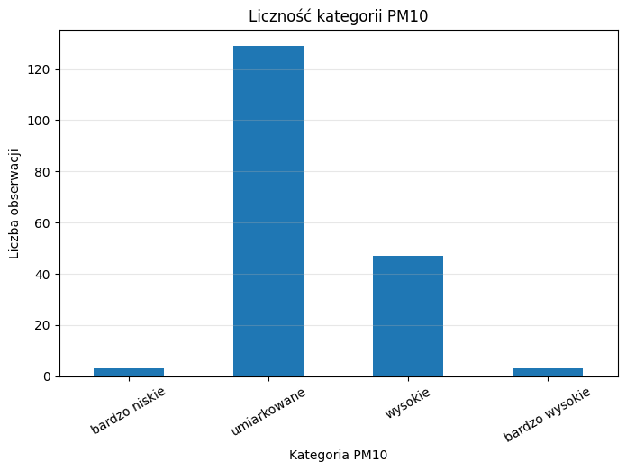

```python
plt.figure(figsize=(8, 5))
pm10_counts.plot(kind="bar")
plt.title("Liczność kategorii PM10")
plt.xlabel("Kategoria PM10")
plt.ylabel("Liczba obserwacji")
plt.xticks(rotation=30)
plt.grid(axis="y", alpha=0.3)
plt.show()
```

```python
# H0: obserwacje są równomiernie rozłożone między kategoriami PM10.
# H1: obserwacje nie są równomiernie rozłożone między kategoriami PM10.
chi_stat, p_value = chisquare(pm10_counts)

print("Test chi-kwadrat dla kategorii PM10")
print("chi2:", chi_stat)
print("p-value:", p_value)

if p_value < alpha:
    print("Odrzucamy H0 - obserwacje nie są równomiernie rozłożone między kategoriami PM10.")
else:
    print("Brak podstaw do odrzucenia H0 - nie wykazano istotnych różnic liczności między kategoriami PM10.")
```

```
Test chi-kwadrat dla kategorii PM10
chi2: 232.68131868131866
p-value: 3.6397289150909396e-50
Odrzucamy H0 - obserwacje nie są równomiernie rozłożone między kategoriami PM10.
```

```python
# 95% przedział ufności dla średniego PM10

pm10 = df_clean["PM10"].dropna()

mean_pm10 = pm10.mean()
sem_pm10 = st.sem(pm10)

ci_pm10 = st.t.interval(
    confidence=0.95,
    df=len(pm10)-1,
    loc=mean_pm10,
    scale=sem_pm10
)

print("Średnia PM10:", mean_pm10)
print(f"95% przedział ufności dla średniej PM10: ({ci_pm10[0]:.2f}, {ci_pm10[1]:.2f})")
```

```
Średnia PM10: 43.281111802604805
95% przedział ufności dla średniej PM10: (40.33, 46.23)
```

```python
j45_rate = df_clean["J45_na_100k"].dropna()

mean_j45_rate = j45_rate.mean()
sem_j45_rate = st.sem(j45_rate)

ci_j45_rate = st.t.interval(
    confidence=0.95,
    df=len(j45_rate)-1,
    loc=mean_j45_rate,
    scale=sem_j45_rate
)

print(f"Średnia J45 na 100 000 mieszkańców: {mean_j45_rate:.2f}")
print(f"95% przedział ufności dla średniej J45 na 100 000 mieszkańców: ({ci_j45_rate[0]:.2f}, {ci_j45_rate[1]:.2f})")
```

```
Średnia J45 na 100 000 mieszkańców: 896.75
95% przedział ufności dla średniej J45 na 100 000 mieszkańców: (873.22, 920.29)
```

# III. Korelacja i regresja

```python
# Przygotowanie danych do korelacji i regresji

corr_data = df_clean[["PM10", "J45_na_100k", "Miasto", "Rok", "Miesiac", "Data"]].copy()

corr_data["PM10"] = pd.to_numeric(corr_data["PM10"], errors="coerce")
corr_data["J45_na_100k"] = pd.to_numeric(corr_data["J45_na_100k"], errors="coerce")

corr_data = corr_data.dropna(subset=["PM10", "J45_na_100k"])

display(corr_data.head())
print(corr_data.shape)
```

|  | PM10 | J45_na_100k | Miasto | Rok | Miesiac | Data |
| --- | --- | --- | --- | --- | --- | --- |
| 0 | 19.187994 | 983.317544 | Gliwice | 2007 | 1 | 2007-01-01 |
| 1 | 38.279270 | 864.772307 | Gliwice | 2007 | 2 | 2007-02-01 |
| 2 | 62.601449 | 1028.911866 | Gliwice | 2007 | 3 | 2007-03-01 |
| 3 | 44.388164 | 926.577943 | Gliwice | 2007 | 4 | 2007-04-01 |
| 4 | 28.912873 | 916.952476 | Gliwice | 2007 | 5 | 2007-05-01 |

```
(182, 6)
```

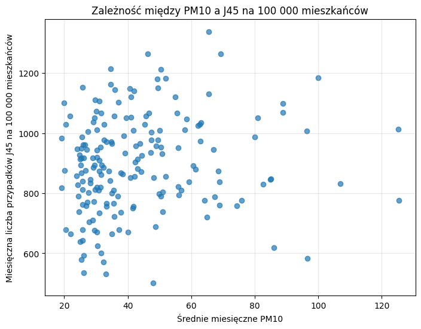

```python
# Wykres punktowy PM10 vs J45
import matplotlib.pyplot as plt

plt.figure(figsize=(8, 6))
plt.scatter(corr_data["PM10"], corr_data["J45_na_100k"], alpha=0.7)
plt.title("Zależność między PM10 a J45 na 100 000 mieszkańców")
plt.xlabel("Średnie miesięczne PM10")
plt.ylabel("Miesięczna liczba przypadków J45 na 100 000 mieszkańców")
plt.grid(alpha=0.3)
plt.show()
```

```python
# Korelacja Pearsona
# H0: Nie istnieje istotna liniowa zależność między PM10 a liczbą przypadków J45.
# H1: Istnieje istotna liniowa zależność między PM10 a liczbą przypadków J45.
from scipy.stats import pearsonr

pearson_corr, pearson_p = pearsonr(corr_data["PM10"], corr_data["J45_na_100k"])

print("Korelacja Pearsona PM10 vs J45 na 100 000 mieszkańców")
print("r =", pearson_corr)
print("p-value =", pearson_p)

if pearson_p < 0.05:
    print("Korelacja Pearsona jest istotna statystycznie.")
else:
    print("Brak podstaw do uznania korelacji Pearsona za istotną statystycznie.")
```

```
Korelacja Pearsona PM10 vs J45 na 100 000 mieszkańców
r = 0.13822765859214223
p-value = 0.06276001363294442
Brak podstaw do uznania korelacji Pearsona za istotną statystycznie.
```

```python
# Interpretacja kierunku
if pearson_corr > 0:
    print("Kierunek zależności: dodatni - wraz ze wzrostem PM10 rośnie J45.")
elif pearson_corr < 0:
    print("Kierunek zależności: ujemny - wraz ze wzrostem PM10 maleje J45.")
else:
    print("Brak zależności liniowej.")
```

```
Kierunek zależności: dodatni - wraz ze wzrostem PM10 rośnie J45.
```

```python
# Korelacja Spearmana
# H0: Nie istnieje istotna monotoniczna zależność między PM10 a liczbą przypadków J45.
# H1: Istnieje istotna monotoniczna zależność między PM10 a liczbą przypadków J45.
from scipy.stats import spearmanr

spearman_corr, spearman_p = spearmanr(corr_data["PM10"], corr_data["J45_na_100k"])

print("Korelacja Spearmana PM10 vs J45 na 100 000 mieszkańców")
print("rho =", spearman_corr)
print("p-value =", spearman_p)

if spearman_p < 0.05:
    print("Korelacja Spearmana jest istotna statystycznie.")
else:
    print("Brak podstaw do uznania korelacji Spearmana za istotną statystycznie.")
```

```
Korelacja Spearmana PM10 vs J45 na 100 000 mieszkańców
rho = 0.1780546235758626
p-value = 0.01618193219496855
Korelacja Spearmana jest istotna statystycznie.
```

```python
# Pomocnicza interpretacja siły korelacji
def interpretuj_korelacje(r):
    abs_r = abs(r)

    if abs_r < 0.2:
        sila = "bardzo słaba"
    elif abs_r < 0.4:
        sila = "słaba"
    elif abs_r < 0.6:
        sila = "umiarkowana"
    elif abs_r < 0.8:
        sila = "silna"
    else:
        sila = "bardzo silna"

    if r > 0:
        kierunek = "dodatnia"
    elif r < 0:
        kierunek = "ujemna"
    else:
        kierunek = "brak kierunku"

    return sila, kierunek

sila_p, kierunek_p = interpretuj_korelacje(pearson_corr)
sila_s, kierunek_s = interpretuj_korelacje(spearman_corr)

print(f"Pearson: korelacja {kierunek_p}, siła: {sila_p}")
print(f"Spearman: korelacja {kierunek_s}, siła: {sila_s}")
```

```
Pearson: korelacja dodatnia, siła: bardzo słaba
Spearman: korelacja dodatnia, siła: bardzo słaba
```

```python
# Korelacja osobno dla Gliwic i Tychów
for miasto in corr_data["Miasto"].unique():
    city_data = corr_data[corr_data["Miasto"] == miasto]

    r, p = pearsonr(city_data["PM10"], city_data["J45_na_100k"])
    rho, p_s = spearmanr(city_data["PM10"], city_data["J45_na_100k"])

    print(f"\nMiasto: {miasto}")
    print(f"Pearson r = {r:.4f}, p-value = {p:.4f}")
    print(f"Spearman rho = {rho:.4f}, p-value = {p_s:.4f}")
```

```
Miasto: Gliwice
Pearson r = 0.1932, p-value = 0.0713
Spearman rho = 0.2482, p-value = 0.0197

Miasto: Tychy
Pearson r = 0.2411, p-value = 0.0193
Spearman rho = 0.3672, p-value = 0.0003
```

```python
# Regresja liniowa: J45 ~ PM10
import statsmodels.api as sm

X = corr_data["PM10"]
y = corr_data["J45_na_100k"]

X = sm.add_constant(X)

model = sm.OLS(y, X).fit()

print(model.summary())

# prostsza interpretacja
print("Współczynnik regresji dla PM10:", model.params["PM10"])
print("Wyraz wolny:", model.params["const"])
print("p-value dla PM10:", model.pvalues["PM10"])
print("R-squared:", model.rsquared)

if model.pvalues["PM10"] < 0.05:
    print("PM10 jest istotnym statystycznie predyktorem liczby przypadków J45 na 100 000 mieszkańców.")
else:
    print("PM10 nie jest istotnym statystycznie predyktorem liczby przypadków J45 na 100 000 mieszkańców.")

print(f"Model wyjaśnia około {model.rsquared * 100:.2f}% zmienności liczby przypadków J45 na 100 000 mieszkańców.")
```

```
                            OLS Regression Results
==============================================================================
Dep. Variable:            J45_na_100k   R-squared:                       0.019
Model:                            OLS   Adj. R-squared:                  0.014
Method:                 Least Squares   F-statistic:                     3.506
Date:                Fri, 19 Jun 2026   Prob (F-statistic):             0.0628
Time:                        16:35:39   Log-Likelihood:                -1180.7
No. Observations:                 182   AIC:                             2365.
Df Residuals:                     180   BIC:                             2372.
Df Model:                           1
Covariance Type:            nonrobust
==============================================================================
                 coef    std err          t      P>|t|      [0.025      0.975]
------------------------------------------------------------------------------
const        849.0578     28.091     30.225      0.000     793.627     904.489
PM10           1.1020      0.589      1.872      0.063      -0.059       2.263
==============================================================================
Omnibus:                        0.539   Durbin-Watson:                   1.131
Prob(Omnibus):                  0.764   Jarque-Bera (JB):                0.662
Skew:                          -0.019   Prob(JB):                        0.718
Kurtosis:                       2.707   Cond. No.                         113.
==============================================================================

Notes:
[1] Standard Errors assume that the covariance matrix of the errors is correctly specified.
Współczynnik regresji dla PM10: 1.1020188972312748
Wyraz wolny: 849.0577744220124
p-value dla PM10: 0.06276001363294498
R-squared: 0.01910688559986584
PM10 nie jest istotnym statystycznie predyktorem liczby przypadków J45 na 100 000 mieszkańców.
Model wyjaśnia około 1.91% zmienności liczby przypadków J45 na 100 000 mieszkańców.
```

### Interpretacja korelacji i regresji

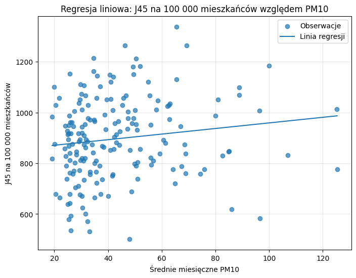

```python
# Wykres punktowy z linią regresji
import numpy as np

plt.figure(figsize=(8, 6))

plt.scatter(corr_data["PM10"], corr_data["J45_na_100k"], alpha=0.7, label="Obserwacje")

x_values = np.linspace(corr_data["PM10"].min(), corr_data["PM10"].max(), 100)
y_values = model.params["const"] + model.params["PM10"] * x_values

plt.plot(x_values, y_values, label="Linia regresji")

plt.title("Regresja liniowa: J45 na 100 000 mieszkańców względem PM10")
plt.xlabel("Średnie miesięczne PM10")
plt.ylabel("J45 na 100 000 mieszkańców")
plt.legend()
plt.grid(alpha=0.3)
plt.show()
```

```python
# Regresja osobno dla miast
for miasto in corr_data["Miasto"].unique():
    city_data = corr_data[corr_data["Miasto"] == miasto]

    X_city = sm.add_constant(city_data["PM10"])
    y_city = city_data["J45_na_100k"]

    model_city = sm.OLS(y_city, X_city).fit()

    print(f"\nRegresja dla miasta: {miasto}")
    print("Współczynnik PM10:", model_city.params["PM10"])
    print("p-value PM10:", model_city.pvalues["PM10"])
    print("R-squared:", model_city.rsquared)
```

```
Regresja dla miasta: Gliwice
Współczynnik PM10: 1.0853835387102495
p-value PM10: 0.07131420080598679
R-squared: 0.03732526823354987

Regresja dla miasta: Tychy
Współczynnik PM10: 2.058913199623831
p-value PM10: 0.01926185170597434
R-squared: 0.05810529869446357
```

# IV. Analiza szeregów czasowych

# Uwzględnienie obu miast

```python
# IV. Analiza szeregów czasowych - przygotowanie danych

import numpy as np
import pandas as pd
import matplotlib.pyplot as plt

from scipy.signal import periodogram
from statsmodels.graphics.tsaplots import plot_acf
from statsmodels.tsa.seasonal import seasonal_decompose

# Upewniamy się, że data istnieje
df_all["Data"] = pd.to_datetime(
    df_all["Rok"].astype(str) + "-" + df_all["Miesiac"].astype(str) + "-01"
)

# Zmienne numeryczne
df_all["PM10"] = pd.to_numeric(df_all["PM10"], errors="coerce")
df_all["J45_na_100k"] = pd.to_numeric(df_all["J45_na_100k"], errors="coerce")

def przygotuj_szereg(df, miasto, zmienna):
    """
    Funkcja przygotowuje miesięczny szereg czasowy dla wybranego miasta i zmiennej.
    Braki są uzupełniane interpolacją liniową, aby zachować ciągłość szeregu.
    """
    ts_data = df[df["Miasto"] == miasto].copy()
    ts_data = ts_data.sort_values("Data")

    ts = ts_data.set_index("Data")[zmienna]
    ts = ts.asfreq("MS")

    print(f"{miasto} - {zmienna}")
    print("Liczba obserwacji:", len(ts))
    print("Liczba braków przed interpolacją:", ts.isna().sum())

    ts_filled = ts.interpolate(method="linear")

    print("Liczba braków po interpolacji:", ts_filled.isna().sum())
    print()

    return ts_filled


# Szeregi czasowe PM10 i J45_na_100k dla obu miast

pm10_gliwice = przygotuj_szereg(df_all, "Gliwice", "PM10")
j45_gliwice = przygotuj_szereg(df_all, "Gliwice", "J45_na_100k")

pm10_tychy = przygotuj_szereg(df_all, "Tychy", "PM10")
j45_tychy = przygotuj_szereg(df_all, "Tychy", "J45_na_100k")
```

```
Gliwice - PM10
Liczba obserwacji: 96
Liczba braków przed interpolacją: 8
Liczba braków po interpolacji: 0

Gliwice - J45_na_100k
Liczba obserwacji: 96
Liczba braków przed interpolacją: 0
Liczba braków po interpolacji: 0

Tychy - PM10
Liczba obserwacji: 96
Liczba braków przed interpolacją: 2
Liczba braków po interpolacji: 0

Tychy - J45_na_100k
Liczba obserwacji: 96
Liczba braków przed interpolacją: 0
Liczba braków po interpolacji: 0
```

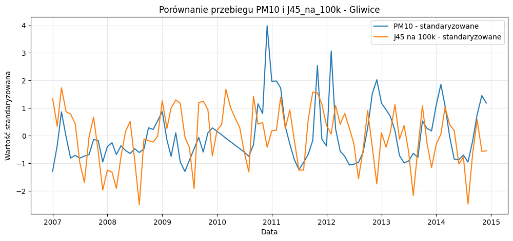

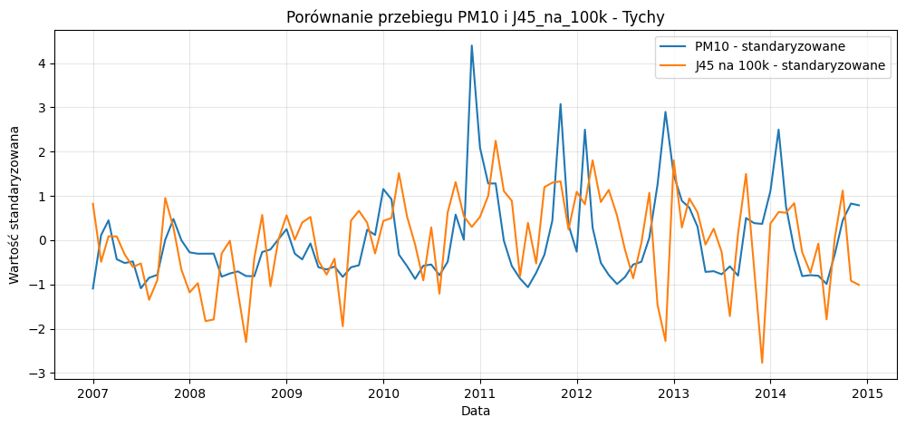

```python
def wykres_porownawczy_standaryzowany(pm10_ts, j45_ts, miasto):
    """
    Wykres pokazuje przebieg PM10 i J45_na_100k w czasie po standaryzacji.
    Dzięki temu można porównywać kształt zmian mimo różnych jednostek.
    """
    pm10_z = (pm10_ts - pm10_ts.mean()) / pm10_ts.std()
    j45_z = (j45_ts - j45_ts.mean()) / j45_ts.std()

    plt.figure(figsize=(12, 5))
    plt.plot(pm10_z.index, pm10_z.values, label="PM10 - standaryzowane")
    plt.plot(j45_z.index, j45_z.values, label="J45 na 100k - standaryzowane")
    plt.title(f"Porównanie przebiegu PM10 i J45_na_100k - {miasto}")
    plt.xlabel("Data")
    plt.ylabel("Wartość standaryzowana")
    plt.legend()
    plt.grid(alpha=0.3)
    plt.show()

wykres_porownawczy_standaryzowany(pm10_gliwice, j45_gliwice, "Gliwice")
wykres_porownawczy_standaryzowany(pm10_tychy, j45_tychy, "Tychy")
```

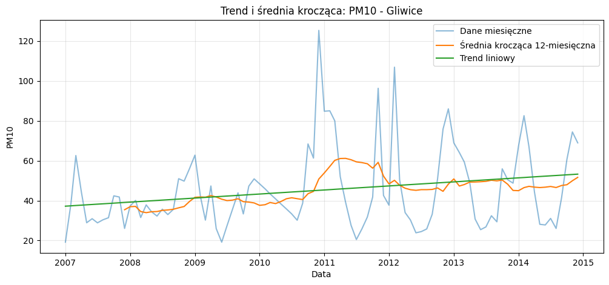

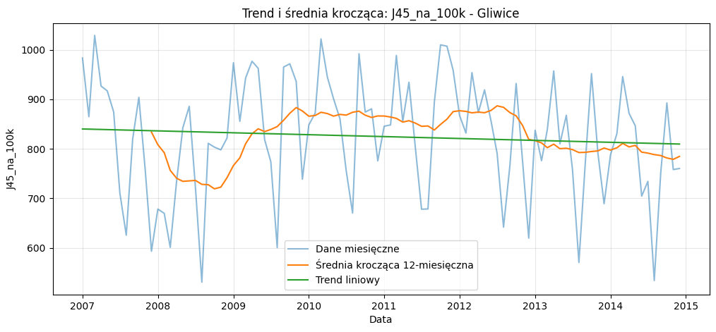

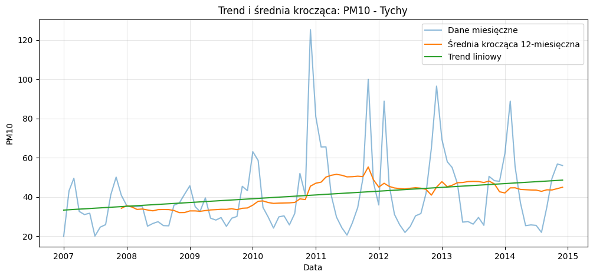

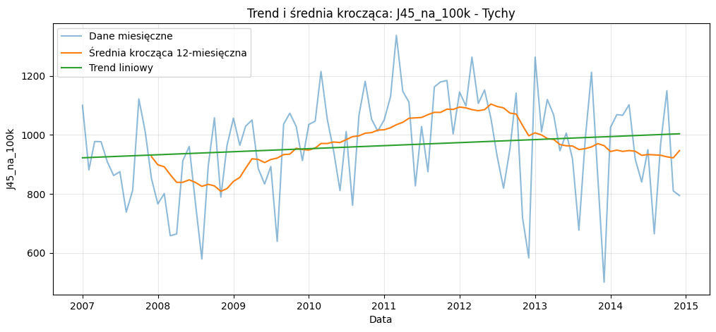

|  | Miasto | Zmienna | Współczynnik trendu | Interpretacja |
| --- | --- | --- | --- | --- |
| 0 | Gliwice | PM10 | 0.169021 | rosnący |
| 1 | Gliwice | J45_na_100k | -0.320239 | malejący |
| 2 | Tychy | PM10 | 0.160821 | rosnący |
| 3 | Tychy | J45_na_100k | 0.857603 | rosnący |

```python
def wykres_trendu_i_sredniej_kroczacej(ts, miasto, zmienna):
    rolling_12 = ts.rolling(window=12).mean()

    time_index = np.arange(len(ts))
    trend_coefficients = np.polyfit(time_index, ts.values, 1)
    trend_line = np.polyval(trend_coefficients, time_index)

    plt.figure(figsize=(12, 5))
    plt.plot(ts.index, ts.values, label="Dane miesięczne", alpha=0.5)
    plt.plot(rolling_12.index, rolling_12.values, label="Średnia krocząca 12-miesięczna")
    plt.plot(ts.index, trend_line, label="Trend liniowy")
    plt.title(f"Trend i średnia krocząca: {zmienna} - {miasto}")
    plt.xlabel("Data")
    plt.ylabel(zmienna)
    plt.legend()
    plt.grid(alpha=0.3)
    plt.show()

    return trend_coefficients[0]

trend_results = []

for miasto, pm10_ts, j45_ts in [
    ("Gliwice", pm10_gliwice, j45_gliwice),
    ("Tychy", pm10_tychy, j45_tychy)
]:
    trend_pm10 = wykres_trendu_i_sredniej_kroczacej(pm10_ts, miasto, "PM10")
    trend_j45 = wykres_trendu_i_sredniej_kroczacej(j45_ts, miasto, "J45_na_100k")

    trend_results.append({
        "Miasto": miasto,
        "Zmienna": "PM10",
        "Współczynnik trendu": trend_pm10,
        "Interpretacja": "rosnący" if trend_pm10 > 0 else "malejący" if trend_pm10 < 0 else "brak trendu"
    })

    trend_results.append({
        "Miasto": miasto,
        "Zmienna": "J45_na_100k",
        "Współczynnik trendu": trend_j45,
        "Interpretacja": "rosnący" if trend_j45 > 0 else "malejący" if trend_j45 < 0 else "brak trendu"
    })

trend_summary = pd.DataFrame(trend_results)
display(trend_summary)
```

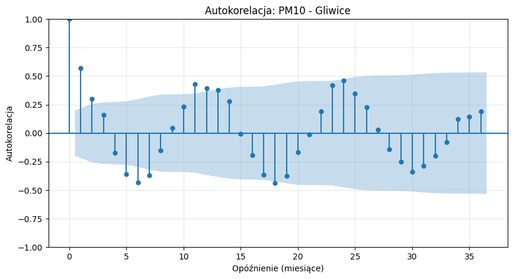

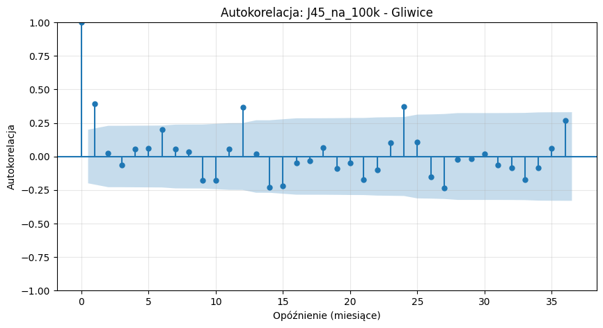

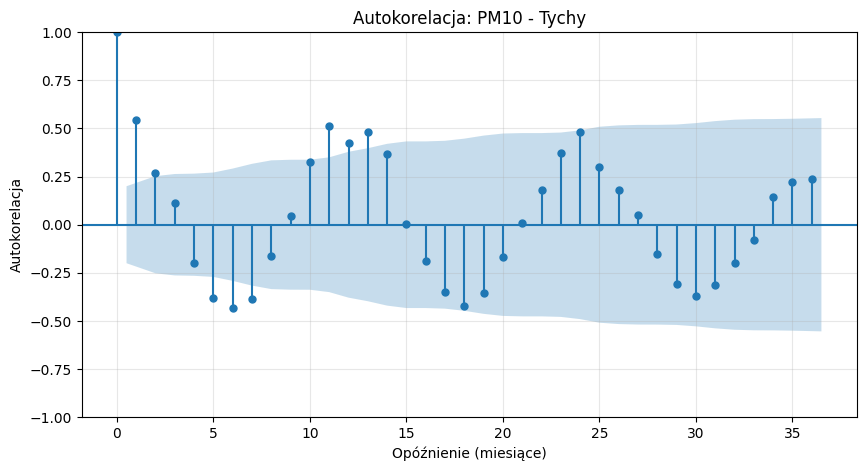

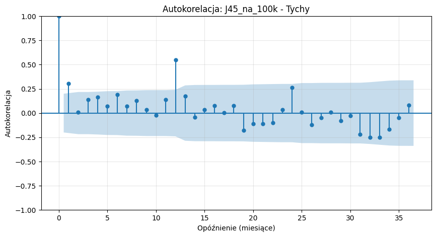

```python
def pokaz_autokorelacje(ts, miasto, zmienna):
    fig, ax = plt.subplots(figsize=(10, 5))
    plot_acf(ts, lags=36, ax=ax)
    ax.set_title(f"Autokorelacja: {zmienna} - {miasto}")
    ax.set_xlabel("Opóźnienie (miesiące)")
    ax.set_ylabel("Autokorelacja")
    ax.grid(alpha=0.3)
    plt.show()

for miasto, pm10_ts, j45_ts in [
    ("Gliwice", pm10_gliwice, j45_gliwice),
    ("Tychy", pm10_tychy, j45_tychy)
]:
    pokaz_autokorelacje(pm10_ts, miasto, "PM10")
    pokaz_autokorelacje(j45_ts, miasto, "J45_na_100k")
```

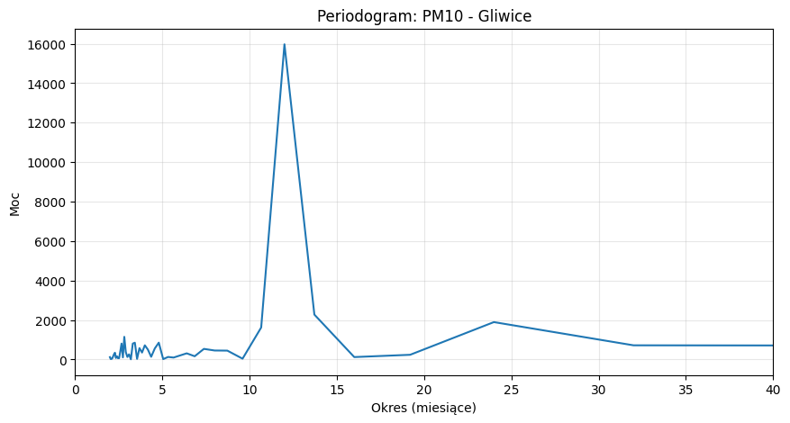

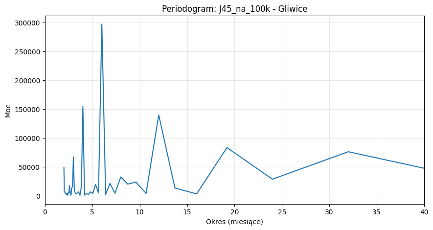

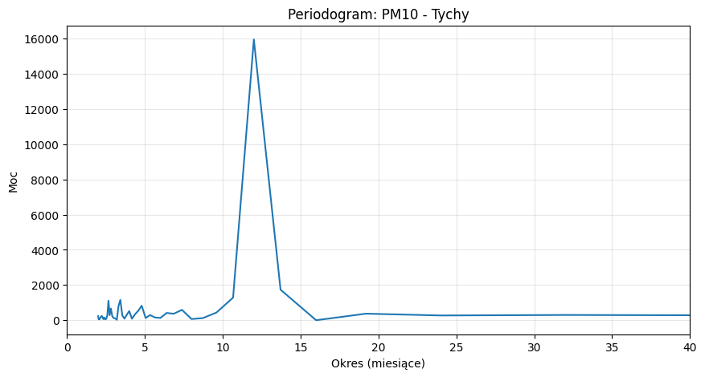

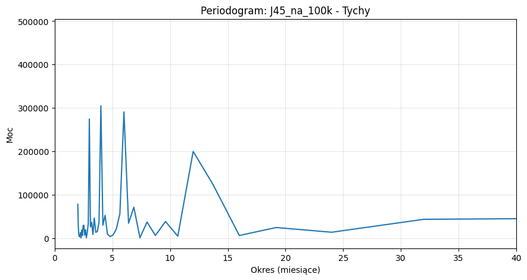

|  | Miasto | Zmienna | Okres_miesiace | Moc |
| --- | --- | --- | --- | --- |
| 0 | Gliwice | PM10 | 12.000000 | 15972.082727 |
| 1 | Gliwice | PM10 | 96.000000 | 2360.244602 |
| 2 | Gliwice | PM10 | 13.714286 | 2275.502476 |
| 3 | Gliwice | PM10 | 24.000000 | 1894.945113 |
| 4 | Gliwice | PM10 | 10.666667 | 1621.111197 |
| 5 | Gliwice | J45_na_100k | 6.000000 | 297499.593227 |
| 6 | Gliwice | J45_na_100k | 4.000000 | 154367.958007 |
| 7 | Gliwice | J45_na_100k | 12.000000 | 139892.251821 |
| 8 | Gliwice | J45_na_100k | 96.000000 | 93795.565631 |
| 9 | Gliwice | J45_na_100k | 19.200000 | 83265.439339 |
| 10 | Tychy | PM10 | 12.000000 | 15951.080121 |
| 11 | Tychy | PM10 | 96.000000 | 2917.456348 |
| 12 | Tychy | PM10 | 13.714286 | 1735.298926 |
| 13 | Tychy | PM10 | 10.666667 | 1285.305361 |
| 14 | Tychy | PM10 | 3.428571 | 1151.235664 |
| 15 | Tychy | J45_na_100k | 96.000000 | 481061.988741 |
| 16 | Tychy | J45_na_100k | 4.000000 | 304861.135578 |
| 17 | Tychy | J45_na_100k | 6.000000 | 290590.354129 |
| 18 | Tychy | J45_na_100k | 3.000000 | 274422.782604 |
| 19 | Tychy | J45_na_100k | 12.000000 | 199539.433450 |

```python
def pokaz_periodogram(ts, miasto, zmienna):
    frequencies, power = periodogram(ts.values)

    frequencies_nonzero = frequencies[1:]
    power_nonzero = power[1:]
    periods = 1 / frequencies_nonzero

    plt.figure(figsize=(10, 5))
    plt.plot(periods, power_nonzero)
    plt.xlim(0, 40)
    plt.title(f"Periodogram: {zmienna} - {miasto}")
    plt.xlabel("Okres (miesiące)")
    plt.ylabel("Moc")
    plt.grid(alpha=0.3)
    plt.show()

    results = pd.DataFrame({
        "Miasto": miasto,
        "Zmienna": zmienna,
        "Okres_miesiace": periods,
        "Moc": power_nonzero
    }).sort_values("Moc", ascending=False)

    return results.head(5)

periodogram_tables = []

for miasto, pm10_ts, j45_ts in [
    ("Gliwice", pm10_gliwice, j45_gliwice),
    ("Tychy", pm10_tychy, j45_tychy)
]:
    periodogram_tables.append(pokaz_periodogram(pm10_ts, miasto, "PM10"))
    periodogram_tables.append(pokaz_periodogram(j45_ts, miasto, "J45_na_100k"))

periodogram_summary = pd.concat(periodogram_tables, ignore_index=True)
display(periodogram_summary)
```